# Problem Set 23: Working with images in Numpy and Matplotlib

## Instructions

Create a markdown document within JupyterLab and answer the questions below using code blocks that generate the correct outputs. We encourage you to include explanatory text in your markdown document.

Write "robust" solutions wherever possible. A good rule of thumb for judging whether your solution is appropriately "robust" is to ask yourself "If I added additional observations or variables to this data set, or if the order of variables changed, would my code still compute the right solution?"

Make sure your markdown is nicely formatted -- use headers, bullets, numbering, etc so that the structure of the document is clear.

When completed, title your Jupyter notebook file as follows (replace XX with the assignment number, e.g. 01, 02, etc):

netid-assignment_XX-Spring2025.ipynb Submit both your Jupyter notebook on your Github repo.

## Problems

1. For the January 2024 image (202401-nasa-vegetation.jpg) show how to extract a region of the image representing Australia and Tasmania. The sub-image should look something like this:

```python
import numpy as np
import matplotlib.pyplot as plt
import matplotlib.image as mpimg
from pathlib import Path
```

```
Full image shape: (1800, 3600, 3)
```

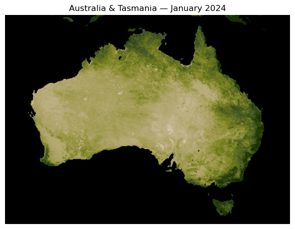

```python
img_dir = Path(r'C:\Users\leoto\Desktop\NASA')

img_jan = mpimg.imread(img_dir / '202401-nasa-vegetation.jpg')

print(f"Full image shape: {img_jan.shape}")   # (height, width, 3)

# Slice the region corresponding to Australia and Tasmania
# Adjust these row/column bounds to match your image dimensions
aus = img_jan[990:1350, 2890:3380]

fig, ax = plt.subplots(figsize=(6, 5))
ax.imshow(aus)
ax.set_title('Australia & Tasmania — January 2024')
ax.axis('off')
plt.tight_layout()
plt.show()
```

2. In these vegetation images, black regions represent regions that were not included in the measurements of vegetation index. In an RGB image, black is represented by the values (0, 0, 0) in terms of the three channels (R, G, B).

Show how to create a Boolean array representing the pixels in the Austalia sub-image that is True for all non-black pixels, and False for all black pixels.

```
Sub-image shape: (360, 490, 3)
Mask shape:      (360, 490)
Land pixels:     83648
Black pixels:    92752
```

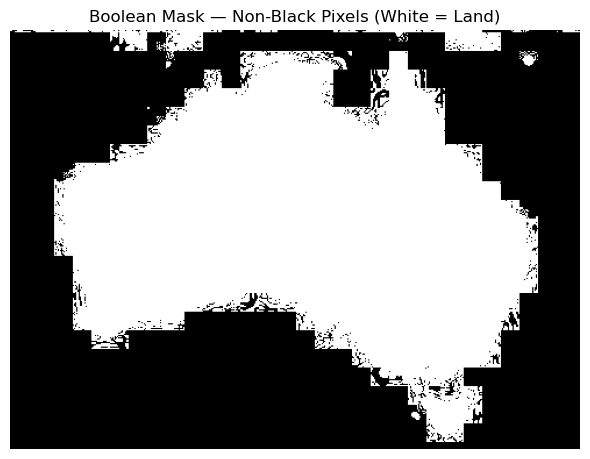

```python
# A pixel is non-black if ANY of its 3 channels (R, G, B) is greater than 0
# np.any(..., axis=2) collapses the 3 colour channels into one True/False per pixel

mask = np.any(aus > 0, axis=2)

print(f"Sub-image shape: {aus.shape}")       # (height, width, 3)
print(f"Mask shape:      {mask.shape}")       # (height, width) — one value per pixel
print(f"Land pixels:     {mask.sum()}")
print(f"Black pixels:    {(~mask).sum()}")

fig, ax = plt.subplots(figsize=(6, 5))
ax.imshow(mask, cmap='gray')
ax.set_title('Boolean Mask — Non-Black Pixels (White = Land)')
ax.axis('off')
plt.tight_layout()
plt.show()
```

3. Using the Boolean mask (array) created in problem 2 and the Australia/Tasmania sub-image from problem 1, show how to extract all the green channel pixel intensities for Australia and Tasmania in the January 2024 image, and calculate the average "greenness" of that sub-image (only considering the land pixels)

```python
green_channel = aus[:, :, 1]
print(f"Green channel shape: {green_channel.shape}")   # (height, width)

green_land = green_channel[mask]
print(f"Number of land pixels: {green_land.shape[0]}")

avg_green_jan = green_land.mean()
print(f"Average green intensity (land only): {avg_green_jan:.2f}")
```

```
Green channel shape: (360, 490)
Number of land pixels: 83648
Average green intensity (land only): 117.88
```

4. Show how to iterate through all the NASA vegetation index images, carrying out steps 1-3 above, and then create a simple line plot showing average green value on the y-axis, and month (represented as integers) on the x-axis.

[output not shown]

[figure not shown]

```python
# Collect all vegetation image files in sorted order (Jan → Dec)
image_files = sorted(image_dir.glob('2024??-nasa-vegetation.jpg'))

print(f"Found {len(image_files)} images:")
for f in image_files:
    print(f"  {f.name}")

# Row/column bounds for the Australia/Tasmania sub-image
ROW_START, ROW_END = 330, 540
COL_START, COL_END = 1150, 1380

# Store results
months     = []
avg_greens = []

for img_path in image_files:

    # Extract month number from filename (e.g. '202401-nasa-vegetation.jpg' → 1)
    month = int(img_path.stem[4:6])

    # Load image
    img = mpimg.imread(str(img_path))

    # Extract Australia/Tasmania sub-image
    aus = img[ROW_START:ROW_END, COL_START:COL_END]

    # Build boolean mask (non-black pixels = land)
    mask = np.any(aus > 0, axis=2)

    # Compute average green intensity for land pixels only
    avg_green = aus[:, :, 1][mask].mean()

    months.append(month)
    avg_greens.append(avg_green)

    print(f"Month {month:02d}: avg green = {avg_green:.2f}  (land pixels: {mask.sum()})")

# Plot
fig, ax = plt.subplots(figsize=(8, 4))

ax.plot(months, avg_greens, marker='o', linewidth=2, color='forestgreen')
ax.set_xlabel('Month', fontsize=12)
ax.set_ylabel('Average Green Intensity', fontsize=12)
ax.set_title('Monthly Average Greenness — Australia & Tasmania, 2024', fontsize=13)
ax.set_xticks(months)
ax.set_xticklabels(['Jan','Feb','Mar','Apr','May','Jun',
                    'Jul','Aug','Sep','Oct','Nov','Dec'])
ax.grid(True, linestyle='--', alpha=0.5)

plt.tight_layout()
plt.show()
```